# Notebook_Capstone_CPI_DA_SDG_8_A

# Hipotesis 3.2

Pekerja non-disabilitas di Indonesia cenderung memiliki upah yang lebih tinggi daripada pekerja disabilitas

```python
# Load Dataset
urlx = 'https://raw.githubusercontent.com/JCalvinL19/CapstoneDAGigih/main/Earnings_Sex%20and%20Disability%20Status.csv'
dfx = pd.read_csv(urlx)
dfx.head()
```

|  | Country | Source | Sex | Disability status | Currency | Year | Value |
| --- | --- | --- | --- | --- | --- | --- | --- |
| 0 | Indonesia | LFS - National Labour Force Survey | Total | Aggregate: Total | Currency: Local currency | 2022 | 2690034.7 |
| 1 | Indonesia | LFS - National Labour Force Survey | Total | Aggregate: Total | Currency: 2017 PPP $ | 2022 | 550.2 |
| 2 | Indonesia | LFS - National Labour Force Survey | Total | Aggregate: Total | Currency: U.S. dollars | 2022 | 181.2 |
| 3 | Indonesia | LFS - National Labour Force Survey | Total | Aggregate: Persons with disability | Currency: Local currency | 2022 | 2042223.5 |
| 4 | Indonesia | LFS - National Labour Force Survey | Total | Aggregate: Persons with disability | Currency: 2017 PPP $ | 2022 | 417.7 |

```python
# Filter dataset dengan kondisi Currency = Local Currency dan Disability Status = Disability)
local_currency = dfx[(dfx['Currency'] == 'Currency: Local currency') & (dfx['Disability status'] == 'Aggregate: Persons with disability') ]

# Group BY Sex, Disability status and Year
result_disability = local_currency.groupby(['Sex', 'Disability status', 'Year'])['Value'].sum().reset_index()
result_disability
```

|  | Sex | Disability status | Year | Value |
| --- | --- | --- | --- | --- |
| 0 | Female | Aggregate: Persons with disability | 2016 | 948206.3 |
| 1 | Female | Aggregate: Persons with disability | 2017 | 1197943.9 |
| 2 | Female | Aggregate: Persons with disability | 2018 | 1223835.4 |
| 3 | Female | Aggregate: Persons with disability | 2019 | 1366903.5 |
| 4 | Female | Aggregate: Persons with disability | 2020 | 1112174.9 |
| 5 | Female | Aggregate: Persons with disability | 2021 | 1813509.1 |
| 6 | Female | Aggregate: Persons with disability | 2022 | 1518797.1 |
| 7 | Male | Aggregate: Persons with disability | 2016 | 1650475.0 |
| 8 | Male | Aggregate: Persons with disability | 2017 | 1876601.4 |
| 9 | Male | Aggregate: Persons with disability | 2018 | 1957560.8 |
| 10 | Male | Aggregate: Persons with disability | 2019 | 1915246.6 |
| 11 | Male | Aggregate: Persons with disability | 2020 | 1970339.9 |
| 12 | Male | Aggregate: Persons with disability | 2021 | 1543602.0 |
| 13 | Male | Aggregate: Persons with disability | 2022 | 2352849.7 |
| 14 | Total | Aggregate: Persons with disability | 2016 | 1449516.3 |
| 15 | Total | Aggregate: Persons with disability | 2017 | 1693967.0 |
| 16 | Total | Aggregate: Persons with disability | 2018 | 1773353.1 |
| 17 | Total | Aggregate: Persons with disability | 2019 | 1741986.4 |
| 18 | Total | Aggregate: Persons with disability | 2020 | 1725574.2 |
| 19 | Total | Aggregate: Persons with disability | 2021 | 1639324.1 |
| 20 | Total | Aggregate: Persons with disability | 2022 | 2042223.5 |

```python
# Hitung rata-rata upah per tahun untuk pekerja disabilitas
average_salary_disability = result_disability.groupby('Year')['Value'].mean()
average_salary_disability
```

```
Year
2016    1.349399e+06
2017    1.589504e+06
2018    1.651583e+06
2019    1.674712e+06
2020    1.602696e+06
2021    1.665478e+06
2022    1.971290e+06
Name: Value, dtype: float64
```

```python
# Hitung rata-rata upah untuk setiap kelompok pekerja
average_disability = result_disability['Value'].mean()
average_disability
```

```
1643523.342857143
```

```python
# Filter dataset dengan kondisi Currency = Local Currency dan Disability Status = Non Disability)
local_currency2 = dfx[(dfx['Currency'] == 'Currency: Local currency') & (dfx['Disability status'] == 'Aggregate: Persons without disability') ]

# Group BY Sex, Disability status and Year
result_non_disability = local_currency2.groupby(['Sex', 'Disability status', 'Year'])['Value'].sum().reset_index()
result_non_disability
```

|  | Sex | Disability status | Year | Value |
| --- | --- | --- | --- | --- |
| 0 | Female | Aggregate: Persons without disability | 2016 | 1832588.8 |
| 1 | Female | Aggregate: Persons without disability | 2017 | 2063587.8 |
| 2 | Female | Aggregate: Persons without disability | 2018 | 2084633.1 |
| 3 | Female | Aggregate: Persons without disability | 2019 | 2183253.0 |
| 4 | Female | Aggregate: Persons without disability | 2020 | 2187807.7 |
| 5 | Female | Aggregate: Persons without disability | 2021 | 2177764.0 |
| 6 | Female | Aggregate: Persons without disability | 2022 | 2280139.5 |
| 7 | Male | Aggregate: Persons without disability | 2016 | 2273441.9 |
| 8 | Male | Aggregate: Persons without disability | 2017 | 2622290.8 |
| 9 | Male | Aggregate: Persons without disability | 2018 | 2659581.9 |
| 10 | Male | Aggregate: Persons without disability | 2019 | 2798110.4 |
| 11 | Male | Aggregate: Persons without disability | 2020 | 2753714.6 |
| 12 | Male | Aggregate: Persons without disability | 2021 | 2680790.1 |
| 13 | Male | Aggregate: Persons without disability | 2022 | 2901912.6 |
| 14 | Total | Aggregate: Persons without disability | 2016 | 2127214.8 |
| 15 | Total | Aggregate: Persons without disability | 2017 | 2435542.7 |
| 16 | Total | Aggregate: Persons without disability | 2018 | 2467031.9 |
| 17 | Total | Aggregate: Persons without disability | 2019 | 2590807.4 |
| 18 | Total | Aggregate: Persons without disability | 2020 | 2562663.0 |
| 19 | Total | Aggregate: Persons without disability | 2021 | 2512484.5 |
| 20 | Total | Aggregate: Persons without disability | 2022 | 2698411.0 |

```python
# Hitung rata-rata upah per tahun untuk pekerja non disabilitas
average_salary_non_disability = result_non_disability.groupby('Year')['Value'].mean()
average_salary_non_disability
```

```
Year
2016    2.077748e+06
2017    2.373807e+06
2018    2.403749e+06
2019    2.524057e+06
2020    2.501395e+06
2021    2.457013e+06
2022    2.626821e+06
Name: Value, dtype: float64
```

```python
# Hitung rata-rata upah untuk setiap kelompok pekerja
average_non_disability = result_non_disability['Value'].mean()
average_non_disability
```

```
2423512.928571428
```

```python
# Filter dataset dengan kondisi Currency = Local Currency dan Disability Status =Disability & Non Disability)
local_currency3 = dfx[(dfx['Currency'] == 'Currency: Local currency') & (dfx['Disability status'] != 'Aggregate: Total') ]

# Group BY Sex, Disability status and Year
result_mix = local_currency3.groupby(['Sex', 'Disability status', 'Year'])['Value'].sum().reset_index()
result_mix
```

|  | Sex | Disability status | Year | Value |
| --- | --- | --- | --- | --- |
| 0 | Female | Aggregate: Persons with disability | 2016 | 948206.3 |
| 1 | Female | Aggregate: Persons with disability | 2017 | 1197943.9 |
| 2 | Female | Aggregate: Persons with disability | 2018 | 1223835.4 |
| 3 | Female | Aggregate: Persons with disability | 2019 | 1366903.5 |
| 4 | Female | Aggregate: Persons with disability | 2020 | 1112174.9 |
| 5 | Female | Aggregate: Persons with disability | 2021 | 1813509.1 |
| 6 | Female | Aggregate: Persons with disability | 2022 | 1518797.1 |
| 7 | Female | Aggregate: Persons without disability | 2016 | 1832588.8 |
| 8 | Female | Aggregate: Persons without disability | 2017 | 2063587.8 |
| 9 | Female | Aggregate: Persons without disability | 2018 | 2084633.1 |
| 10 | Female | Aggregate: Persons without disability | 2019 | 2183253.0 |
| 11 | Female | Aggregate: Persons without disability | 2020 | 2187807.7 |
| 12 | Female | Aggregate: Persons without disability | 2021 | 2177764.0 |
| 13 | Female | Aggregate: Persons without disability | 2022 | 2280139.5 |
| 14 | Male | Aggregate: Persons with disability | 2016 | 1650475.0 |
| 15 | Male | Aggregate: Persons with disability | 2017 | 1876601.4 |
| 16 | Male | Aggregate: Persons with disability | 2018 | 1957560.8 |
| 17 | Male | Aggregate: Persons with disability | 2019 | 1915246.6 |
| 18 | Male | Aggregate: Persons with disability | 2020 | 1970339.9 |
| 19 | Male | Aggregate: Persons with disability | 2021 | 1543602.0 |
| 20 | Male | Aggregate: Persons with disability | 2022 | 2352849.7 |
| 21 | Male | Aggregate: Persons without disability | 2016 | 2273441.9 |
| 22 | Male | Aggregate: Persons without disability | 2017 | 2622290.8 |
| 23 | Male | Aggregate: Persons without disability | 2018 | 2659581.9 |
| 24 | Male | Aggregate: Persons without disability | 2019 | 2798110.4 |
| 25 | Male | Aggregate: Persons without disability | 2020 | 2753714.6 |
| 26 | Male | Aggregate: Persons without disability | 2021 | 2680790.1 |
| 27 | Male | Aggregate: Persons without disability | 2022 | 2901912.6 |
| 28 | Total | Aggregate: Persons with disability | 2016 | 1449516.3 |
| 29 | Total | Aggregate: Persons with disability | 2017 | 1693967.0 |
| 30 | Total | Aggregate: Persons with disability | 2018 | 1773353.1 |
| 31 | Total | Aggregate: Persons with disability | 2019 | 1741986.4 |
| 32 | Total | Aggregate: Persons with disability | 2020 | 1725574.2 |
| 33 | Total | Aggregate: Persons with disability | 2021 | 1639324.1 |
| 34 | Total | Aggregate: Persons with disability | 2022 | 2042223.5 |
| 35 | Total | Aggregate: Persons without disability | 2016 | 2127214.8 |
| 36 | Total | Aggregate: Persons without disability | 2017 | 2435542.7 |
| 37 | Total | Aggregate: Persons without disability | 2018 | 2467031.9 |
| 38 | Total | Aggregate: Persons without disability | 2019 | 2590807.4 |
| 39 | Total | Aggregate: Persons without disability | 2020 | 2562663.0 |
| 40 | Total | Aggregate: Persons without disability | 2021 | 2512484.5 |
| 41 | Total | Aggregate: Persons without disability | 2022 | 2698411.0 |

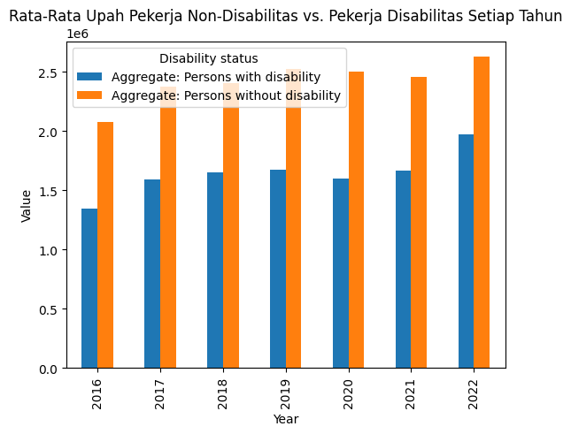

```python
# Create a bar plot
plt.figure(figsize=(10, 6))

# Pivot the data to create separate bars for each group
pivot_result_mix = result_mix.pivot_table(index=['Year'], columns=['Disability status'], values='Value')
pivot_result_mix.plot(kind='bar', stacked=False)

plt.xlabel('Year')
plt.ylabel('Value')
plt.title('Rata-Rata Upah Pekerja Non-Disabilitas vs. Pekerja Disabilitas Setiap Tahun')
plt.legend(title='Disability status')
plt.show()
```

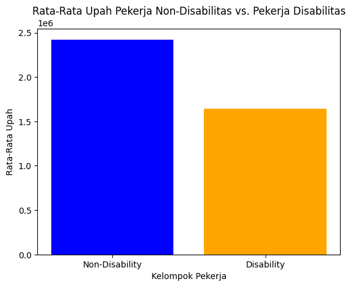

```python
# Data untuk visualisasi
categories = ['Non-Disability', 'Disability']
average_salaries = [average_non_disability, average_disability]

# Membuat grafik batang
plt.bar(categories, average_salaries, color=['blue', 'orange'])
plt.title('Rata-Rata Upah Pekerja Non-Disabilitas vs. Pekerja Disabilitas')
plt.xlabel('Kelompok Pekerja')
plt.ylabel('Rata-Rata Upah')
plt.show()
```

```python
# Hitung perbedaan persentase upah
percentage_more_non_disability = ((average_non_disability - average_disability) / average_disability) * 100
percentage_less_disability = ((average_disability - average_non_disability) / average_non_disability) * 100

# Cetak hasil
print("Persentase upah non-disabilitas lebih banyak dibandingkan disabilitas:", percentage_more_non_disability, "%")
print("Persentase upah disabilitas lebih sedikit dibandingkan non-disabilitas:", percentage_less_disability, "%")
```

```
Persentase upah non-disabilitas lebih banyak dibandingkan disabilitas: 47.458381963613085 %
Persentase upah disabilitas lebih sedikit dibandingkan non-disabilitas: -32.18425519908658 %
```

KESIMPULAN:

Hasil analisis data dari tahun 2016 hingga 2022 menunjukkan bahwa hipotesis yang menyatakan bahwa pekerja non-disabilitas di Indonesia cenderung memiliki upah yang lebih tinggi daripada pekerja disabilitas ternyata benar. Rata-rata upah untuk pekerja non-disabilitas adalah sekitar Rp. 2.423.512,92, sementara rata-rata upah untuk pekerja disabilitas adalah sekitar Rp.1.643.523,34. Dalam periode tersebut, data menegaskan bahwa pekerja non-disabilitas memiliki upah yang 47,45% lebih tinggi daripada pekerja disabilitas. Ini mengindikasikan adanya ketidaksetaraan upah yang signifikan antara dua kelompok ini. Sebaliknya, pekerja disabilitas memiliki upah yang 32,18% lebih rendah daripada pekerja non-disabilitas.

**CONCLUSION:**

The results of data analysis from 2016 to 2022 confirm the hypothesis that non-disabled workers in Indonesia tend to have higher wages compared to disabled workers. The average wage for non-disabled workers is approximately IDR 2,423,512.92, while the average wage for disabled workers is approximately IDR 1,643,523.34. During this period, the data underscores that non-disabled workers earn 47.45% more than disabled workers. This indicates a significant wage disparity between these two groups. Conversely, disabled workers earn 32.18% less than non-disabled workers.

# Hypothesis 4

There are still several employment sectors where workers earn less than the minimum wage, some of which come from the industry, transportation, trade, hospitality, and service sectors.

Berdasarkan artikel : (https://gajimu.com/gaji/copy_of_kampanye-upah-minimum/pelanggaran-ump)

Dataset:

```python
# Importing the Anual Monthly Earnings of Employees by Sex and Economic Activity Data
url4 = "https://raw.githubusercontent.com/davidkevinhh/Python/main/sex_economic_activity.csv"
df4 = pd.read_csv(url4)

# Showing the First 5 Rows of the Data
df4.head()
```

|  | Country | Sex | Economic Activity | Currency | Year | Earning |
| --- | --- | --- | --- | --- | --- | --- |
| 0 | Indonesia | Sex: Total | Economic activity (Aggregate): Total | Currency: Local currency | 2022 | 2690034.69 |
| 1 | Indonesia | Sex: Total | Economic activity (Aggregate): Total | Currency: 2017 PPP $ | 2022 | 550.19 |
| 2 | Indonesia | Sex: Total | Economic activity (Aggregate): Total | Currency: U.S. dollars | 2022 | 181.15 |
| 3 | Indonesia | Sex: Total | Economic activity (Aggregate): Agriculture | Currency: Local currency | 2022 | 1531773.08 |
| 4 | Indonesia | Sex: Total | Economic activity (Aggregate): Agriculture | Currency: 2017 PPP $ | 2022 | 313.29 |

```python
df4['Economic Activity'].unique()
```

```
array(['Economic activity (Aggregate): Total',
       'Economic activity (Aggregate): Agriculture',
       'Economic activity (Aggregate): Manufacturing',
       'Economic activity (Aggregate): Construction',
       'Economic activity (Aggregate): Mining and quarrying; Electricity, gas and water supply',
       'Economic activity (Aggregate): Trade, Transportation, Accommodation and Food, and Business and Administrative Services',
       'Economic activity (Aggregate): Public Administration, Community, Social and other Services and Activities',
       'Economic activity (ISIC-Rev.4): Total',
       'Economic activity (ISIC-Rev.4): A. Agriculture; forestry and fishing',
       'Economic activity (ISIC-Rev.4): B. Mining and quarrying',
       'Economic activity (ISIC-Rev.4): C. Manufacturing',
       'Economic activity (ISIC-Rev.4): D. Electricity; gas, steam and air conditioning supply',
       'Economic activity (ISIC-Rev.4): E. Water supply; sewerage, waste management and remediation activities',
       'Economic activity (ISIC-Rev.4): F. Construction',
       'Economic activity (ISIC-Rev.4): G. Wholesale and retail trade; repair of motor vehicles and motorcycles',
       'Economic activity (ISIC-Rev.4): H. Transportation and storage',
       'Economic activity (ISIC-Rev.4): I. Accommodation and food service activities',
       'Economic activity (ISIC-Rev.4): J. Information and communication',
       'Economic activity (ISIC-Rev.4): K. Financial and insurance activities',
       'Economic activity (ISIC-Rev.4): L. Real estate activities',
       'Economic activity (ISIC-Rev.4): M. Professional, scientific and technical activities',
       'Economic activity (ISIC-Rev.4): N. Administrative and support service activities',
       'Economic activity (ISIC-Rev.4): O. Public administration and defence; compulsory social security',
       'Economic activity (ISIC-Rev.4): P. Education',
       'Economic activity (ISIC-Rev.4): Q. Human health and social work activities',
       'Economic activity (ISIC-Rev.4): R. Arts, entertainment and recreation',
       'Economic activity (ISIC-Rev.4): S. Other service activities',
       'Economic activity (ISIC-Rev.4): T. Activities of households as employers; undifferentiated goods- and services-producing activities of households for own use',
       'Economic activity (ISIC-Rev.4): U. Activities of extraterritorial organizations and bodies'],
      dtype=object)
```

```python
local_currency_data = df4[
    (df4['Currency'] == 'Currency: Local currency') &
    (df4['Sex'] == 'Sex: Total') &
    (df4['Economic Activity'].str.contains('(Aggregate)')) &
    (df4['Year'] >= 2016)]

status_mapping = {
    'Economic activity (Aggregate): Agriculture': 'Agriculture',
    'Economic activity (Aggregate): Construction': 'Construction',
    'Economic activity (Aggregate): Manufacturing': 'Manufacturing',
    'Economic activity (Aggregate): Total': 'Total',
    'Economic activity (Aggregate): Mining and quarrying; Electricity, gas and water supply': 'Mining and quarrying',
    'Economic activity (Aggregate): Public Administration, Community, Social and other Services and Activities': 'Public Administration and Others',
    'Economic activity (Aggregate): Trade, Transportation, Accommodation and Food, and Business and Administrative Services': 'Trade, Transportation, and Others'
}

local_currency_data.loc[:, 'Economic Activity'] = local_currency_data['Economic Activity'].map(status_mapping)

result = local_currency_data.groupby(['Economic Activity', 'Year'])['Earning'].sum().reset_index()
econ_earn = result.pivot(index='Year', columns='Economic Activity', values='Earning')

print("Note:")
print("Public Administration and Others = Public Administration, Community, Social and other Services and Activities")
print("Trade, Transportation, and Others = Trade, Transportation, Accommodation and Food, and Business and Administrative Services")
econ_earn
```

```
Note:
Public Administration and Others = Public Administration, Community, Social and other Services and Activities
Trade, Transportation, and Others = Trade, Transportation, Accommodation and Food, and Business and Administrative Services
```

| Economic Activity Year | Agriculture | Construction | Manufacturing | Mining and quarrying | Public Administration and Others | Total | Trade, Transportation, and Others |
| --- | --- | --- | --- | --- | --- | --- | --- |
| 2016 | 1162169.68 | 1931516.55 | 2088512.55 | 3191607.09 | 2458523.90 | 2125593.66 | 2351462.47 |
| 2017 | 1270646.34 | 2110825.91 | 2435171.13 | 3667850.58 | 2857720.83 | 2433700.75 | 2677234.58 |
| 2018 | 1343856.36 | 2203202.67 | 2479048.04 | 3568360.51 | 2785821.43 | 2465848.92 | 2712373.69 |
| 2019 | 1489810.20 | 2402763.50 | 2638540.95 | 3876490.47 | 2841382.87 | 2589312.73 | 2818922.29 |
| 2020 | 1417576.53 | 2421813.13 | 2638697.49 | 3860530.99 | 2847253.10 | 2561509.93 | 2778900.63 |
| 2021 | 1397337.38 | 2319221.15 | 2664127.55 | 3467763.29 | 2821090.49 | 2511508.12 | 2699775.81 |
| 2022 | 1531773.08 | 2580279.15 | 2802049.97 | 3830233.35 | 2869904.54 | 2690034.69 | 3016989.81 |

```python
df_ump_indo = df_ump[df_ump['Provinsi'] == 'Indonesia']
df_ump_indo
```

|  | Provinsi | Tahun | UMR/UMP |
| --- | --- | --- | --- |
| 34 | Indonesia | 2016 | NaN |
| 69 | Indonesia | 2017 | 2074151.0 |
| 104 | Indonesia | 2018 | 2268874.0 |
| 139 | Indonesia | 2019 | 2455662.0 |
| 174 | Indonesia | 2020 | 2672371.0 |
| 209 | Indonesia | 2021 | 2687724.0 |
| 244 | Indonesia | 2022 | 2725505.0 |

```python
# Membandingkan gaji (berdasarkan Disability Status) dengan UMR dari tahun ke tahun
df_ump_indo = df_ump_indo.dropna(subset=['UMR/UMP'])

# Merge the two DataFrames based on the 'Year' and 'Tahun' columns
merged_df = pd.merge(econ_earn, df_ump_indo, left_index=True, right_on='Tahun', how='inner')

# Create a new column based on the comparison
merged_df['UMR vs A'] = np.where(merged_df['UMR/UMP'] < merged_df['Agriculture'], 'Di atas UMR', 'Di bawah UMR')
merged_df['UMR vs C'] = np.where(merged_df['UMR/UMP'] < merged_df['Construction'], 'Di atas UMR', 'Di bawah UMR')
merged_df['UMR vs M'] = np.where(merged_df['UMR/UMP'] < merged_df['Manufacturing'], 'Di atas UMR', 'Di bawah UMR')
merged_df['UMR vs MQ'] = np.where(merged_df['UMR/UMP'] < merged_df['Mining and quarrying'], 'Di atas UMR', 'Di bawah UMR')
merged_df['UMR vs PA'] = np.where(merged_df['UMR/UMP'] < merged_df['Public Administration and Others'], 'Di atas UMR', 'Di bawah UMR')
merged_df['UMR vs zyy'] = np.where(merged_df['UMR/UMP'] < merged_df['Trade, Transportation, and Others'], 'Di atas UMR', 'Di bawah UMR')

# Drop unnecessary columns
merged_df = merged_df.drop(['Provinsi', 'Total'], axis=1).reset_index(drop=True)
merged_df
```

|  | Agriculture | Construction | Manufacturing | Mining and quarrying | Public Administration and Others | Trade, Transportation, and Others | Tahun | UMR/UMP | UMR vs A | UMR vs C | UMR vs M | UMR vs MQ | UMR vs PA | UMR vs zyy |
| --- | --- | --- | --- | --- | --- | --- | --- | --- | --- | --- | --- | --- | --- | --- |
| 0 | 1270646.34 | 2110825.91 | 2435171.13 | 3667850.58 | 2857720.83 | 2677234.58 | 2017 | 2074151.0 | Di bawah UMR | Di atas UMR | Di atas UMR | Di atas UMR | Di atas UMR | Di atas UMR |
| 1 | 1343856.36 | 2203202.67 | 2479048.04 | 3568360.51 | 2785821.43 | 2712373.69 | 2018 | 2268874.0 | Di bawah UMR | Di bawah UMR | Di atas UMR | Di atas UMR | Di atas UMR | Di atas UMR |
| 2 | 1489810.20 | 2402763.50 | 2638540.95 | 3876490.47 | 2841382.87 | 2818922.29 | 2019 | 2455662.0 | Di bawah UMR | Di bawah UMR | Di atas UMR | Di atas UMR | Di atas UMR | Di atas UMR |
| 3 | 1417576.53 | 2421813.13 | 2638697.49 | 3860530.99 | 2847253.10 | 2778900.63 | 2020 | 2672371.0 | Di bawah UMR | Di bawah UMR | Di bawah UMR | Di atas UMR | Di atas UMR | Di atas UMR |
| 4 | 1397337.38 | 2319221.15 | 2664127.55 | 3467763.29 | 2821090.49 | 2699775.81 | 2021 | 2687724.0 | Di bawah UMR | Di bawah UMR | Di bawah UMR | Di atas UMR | Di atas UMR | Di atas UMR |
| 5 | 1531773.08 | 2580279.15 | 2802049.97 | 3830233.35 | 2869904.54 | 3016989.81 | 2022 | 2725505.0 | Di bawah UMR | Di bawah UMR | Di atas UMR | Di atas UMR | Di atas UMR | Di atas UMR |

## Hypothesis 4.1

The wage disparity by gender in Indonesia can vary by economics activity sector, with certain sectors paying higher wages to women than men.

> Based on the results of the Indonesia Ministry of Labor's publication on Ketenagakerjaan dalam Angka 2021, of the 17 available sectors, there are 6 sectors, including Electricity and Gas Supply, Water Supply, Waste and Recycling Management, Construction, Transportation and Storage, Real Estate, and Corporate Services sectors where female workers/employees/employees have a greater average monthly wage than male workers/employees/employees. In other words, the combination of the business sector and the gender of the worker/employee/employee affects the variation in wages received.

The data used to answer hypothesis no 7 is acquired from International Labour Organization Statistics (ILOSTAT) through https://www.ilo.org/shinyapps/bulkexplorer15/?lang=en&id=EAR_4MTH_SEX_OCU_CUR_NB_A

> The earnings of employees relate to the gross remuneration in cash and in kind paid to employees, as a rule at regular intervals, for time worked or work done together with remuneration for time not worked, such as annual vacation, other type of paid leave or holidays. Earnings exclude employers' contributions in respect of their employees paid to social security and pension schemes and also the benefits received by employees under these schemes. Earnings also exclude severance and termination pay. This is a harmonized series: (1) data reported as weekly, monthly and yearly are converted to hourly using data on average weekly hours if available; and (2) data are converted to U.S. dollars as the common currency, using exchange rates or using purchasing power parity (PPP) rates for private consumption expenditures. The latter series allows for international comparisons by taking account of the differences in relative prices between countries. Data disaggregated by economic activity are provided according to the latest version of the International Standard Industrial Classification of All Economic Activities (ISIC) available for that year. Data may have been regrouped from national classifications, which may not be strictly compatible with ISIC.

```python
# Importing the Anual Monthly Earnings of Employees by Sex and Economic Activity Data
url_economic_activity = "https://raw.githubusercontent.com/davidkevinhh/Python/main/sex_economic_activity.csv"
data_economic_activity = pd.read_csv(url_economic_activity)

# Showing the First 5 Rows of the Data
data_economic_activity.head()
```

|  | Country | Sex | Economic Activity | Currency | Year | Earning |
| --- | --- | --- | --- | --- | --- | --- |
| 0 | Indonesia | Sex: Total | Economic activity (Aggregate): Total | Currency: Local currency | 2022 | 2690034.69 |
| 1 | Indonesia | Sex: Total | Economic activity (Aggregate): Total | Currency: 2017 PPP $ | 2022 | 550.19 |
| 2 | Indonesia | Sex: Total | Economic activity (Aggregate): Total | Currency: U.S. dollars | 2022 | 181.15 |
| 3 | Indonesia | Sex: Total | Economic activity (Aggregate): Agriculture | Currency: Local currency | 2022 | 1531773.08 |
| 4 | Indonesia | Sex: Total | Economic activity (Aggregate): Agriculture | Currency: 2017 PPP $ | 2022 | 313.29 |

```python
# Showing the General Info about the Data
data_economic_activity.info()
```

```
<class 'pandas.core.frame.DataFrame'>
RangeIndex: 1455 entries, 0 to 1454
Data columns (total 6 columns):
 #   Column             Non-Null Count  Dtype
---  ------             --------------  -----
 0   Country            1455 non-null   object
 1   Sex                1455 non-null   object
 2   Economic Activity  1455 non-null   object
 3   Currency           1455 non-null   object
 4   Year               1455 non-null   int64
 5   Earning            1455 non-null   float64
dtypes: float64(1), int64(1), object(4)
memory usage: 68.3+ KB
```

```python
# Rename the values in Sex column to be clearer
data_economic_activity.loc[data_economic_activity["Sex"] == "Sex: Total", "Sex"] = "Total"
data_economic_activity.loc[data_economic_activity["Sex"] == "Sex: Male", "Sex"] = "Male"
data_economic_activity.loc[data_economic_activity["Sex"] == "Sex: Female", "Sex"] = "Female"

# Showing number of rows for each 'Sex'
data_economic_activity['Sex'].value_counts()
```

```
Total     486
Male      486
Female    483
Name: Sex, dtype: int64
```

> We can see that the data for each sex is pretty balanced, with only 3 count differences. The male earnings are 486 rows in total and 483 rows for the female earnings. There are also 486 rows showing for the aggregated sex (male + female). With this, we can explore more for insights about the sex disparity in certain economic activities.

```python
# Showing number of rows for each 'Year'
data_economic_activity['Year'].value_counts()
```

```
2015    258
2014    252
2013    252
2012    252
2022     63
2021     63
2020     63
2019     63
2018     63
2017     63
2016     63
Name: Year, dtype: int64
```

The data is provided from 2012-2022. There are some differences of the rows number, 2012-2014 has 252 rows, 2015 has 258 rows, and 2016-2022 has 2022 has 63 rows. However, the differences should cause no problem since we will only explore the data from 2016 until 2022.

```python
# Showing number of rows for each 'Economic Activity'
data_economic_activity['Economic Activity'].value_counts()
```

```
Economic activity (Aggregate): Total                                                                                                                             99
Economic activity (Aggregate): Manufacturing                                                                                                                     99
Economic activity (Aggregate): Construction                                                                                                                      99
Economic activity (Aggregate): Mining and quarrying; Electricity, gas and water supply                                                                           99
Economic activity (Aggregate): Trade, Transportation, Accommodation and Food, and Business and Administrative Services                                           99
Economic activity (Aggregate): Public Administration, Community, Social and other Services and Activities                                                        99
Economic activity (Aggregate): Agriculture                                                                                                                       99
Economic activity (ISIC-Rev.4): P. Education                                                                                                                     36
Economic activity (ISIC-Rev.4): M. Professional, scientific and technical activities                                                                             36
Economic activity (ISIC-Rev.4): N. Administrative and support service activities                                                                                 36
Economic activity (ISIC-Rev.4): O. Public administration and defence; compulsory social security                                                                 36
Economic activity (ISIC-Rev.4): S. Other service activities                                                                                                      36
Economic activity (ISIC-Rev.4): Q. Human health and social work activities                                                                                       36
Economic activity (ISIC-Rev.4): R. Arts, entertainment and recreation                                                                                            36
Economic activity (ISIC-Rev.4): K. Financial and insurance activities                                                                                            36
Economic activity (ISIC-Rev.4): T. Activities of households as employers; undifferentiated goods- and services-producing activities of households for own use    36
Economic activity (ISIC-Rev.4): L. Real estate activities                                                                                                        36
Economic activity (ISIC-Rev.4): G. Wholesale and retail trade; repair of motor vehicles and motorcycles                                                          36
Economic activity (ISIC-Rev.4): J. Information and communication                                                                                                 36
Economic activity (ISIC-Rev.4): I. Accommodation and food service activities                                                                                     36
Economic activity (ISIC-Rev.4): H. Transportation and storage                                                                                                    36
Economic activity (ISIC-Rev.4): F. Construction                                                                                                                  36
Economic activity (ISIC-Rev.4): E. Water supply; sewerage, waste management and remediation activities                                                           36
Economic activity (ISIC-Rev.4): D. Electricity; gas, steam and air conditioning supply                                                                           36
Economic activity (ISIC-Rev.4): C. Manufacturing                                                                                                                 36
Economic activity (ISIC-Rev.4): B. Mining and quarrying                                                                                                          36
Economic activity (ISIC-Rev.4): A. Agriculture; forestry and fishing                                                                                             36
Economic activity (ISIC-Rev.4): Total                                                                                                                            36
Economic activity (ISIC-Rev.4): U. Activities of extraterritorial organizations and bodies                                                                        6
Name: Economic Activity, dtype: int64
```

> We see there are economic activities categorized by **aggregate** and **International Standard Industrial Classification of All Economic Activities Revision 4 (ISIC-Rev.4)**. For aggregated category, there are 6 types of economic activities, including Manufacturing; Construction; Mining and quarrying - Electricity, gas and water supply; Trade, Transportation, Accommodation and Food, and Business and Administrative Services; Public Administration, Community, Social and other Services and Activities; and Agriculture. For the ISIC-Rev.4 category, there are 21 types of economic activities, which can be seen above. We will try to see the insight based on both categories.

```python
# Creating a subset with only 'ISIC-Rev.4' Economic Activities excluding Total
isic_category = data_economic_activity.loc[(data_economic_activity['Economic Activity'].str.contains('ISIC-Rev.4')) & (data_economic_activity['Economic Activity'] != 'Economic activity (ISIC-Rev.4): Total')]
isic_category['Economic Activity'].value_counts()
```

```
Economic activity (ISIC-Rev.4): A. Agriculture; forestry and fishing                                                                                             36
Economic activity (ISIC-Rev.4): L. Real estate activities                                                                                                        36
Economic activity (ISIC-Rev.4): T. Activities of households as employers; undifferentiated goods- and services-producing activities of households for own use    36
Economic activity (ISIC-Rev.4): S. Other service activities                                                                                                      36
Economic activity (ISIC-Rev.4): R. Arts, entertainment and recreation                                                                                            36
Economic activity (ISIC-Rev.4): Q. Human health and social work activities                                                                                       36
Economic activity (ISIC-Rev.4): P. Education                                                                                                                     36
Economic activity (ISIC-Rev.4): O. Public administration and defence; compulsory social security                                                                 36
Economic activity (ISIC-Rev.4): N. Administrative and support service activities                                                                                 36
Economic activity (ISIC-Rev.4): M. Professional, scientific and technical activities                                                                             36
Economic activity (ISIC-Rev.4): K. Financial and insurance activities                                                                                            36
Economic activity (ISIC-Rev.4): B. Mining and quarrying                                                                                                          36
Economic activity (ISIC-Rev.4): J. Information and communication                                                                                                 36
Economic activity (ISIC-Rev.4): I. Accommodation and food service activities                                                                                     36
Economic activity (ISIC-Rev.4): H. Transportation and storage                                                                                                    36
Economic activity (ISIC-Rev.4): G. Wholesale and retail trade; repair of motor vehicles and motorcycles                                                          36
Economic activity (ISIC-Rev.4): F. Construction                                                                                                                  36
Economic activity (ISIC-Rev.4): E. Water supply; sewerage, waste management and remediation activities                                                           36
Economic activity (ISIC-Rev.4): D. Electricity; gas, steam and air conditioning supply                                                                           36
Economic activity (ISIC-Rev.4): C. Manufacturing                                                                                                                 36
Economic activity (ISIC-Rev.4): U. Activities of extraterritorial organizations and bodies                                                                        6
Name: Economic Activity, dtype: int64
```

```python
# Break down each year data
isic_category['Year'].value_counts()
```

```
2015    186
2014    180
2013    180
2012    180
Name: Year, dtype: int64
```

> Unfortunately, there are no available data of the ISIC-Rev.4 category for 2016-2022 which are the years we'd like to explore. Therefore, we will try to look into the aggregate category

```python
# Creating a subset with only 'Aggregate' Economic Activities excluding Total
aggregate_category = data_economic_activity.loc[(data_economic_activity['Economic Activity'].str.contains('Aggregate')) & (data_economic_activity['Economic Activity'] != 'Economic activity (Aggregate): Total')]
aggregate_category['Economic Activity'].value_counts()
```

```
Economic activity (Aggregate): Agriculture                                                                                99
Economic activity (Aggregate): Manufacturing                                                                              99
Economic activity (Aggregate): Construction                                                                               99
Economic activity (Aggregate): Mining and quarrying; Electricity, gas and water supply                                    99
Economic activity (Aggregate): Trade, Transportation, Accommodation and Food, and Business and Administrative Services    99
Economic activity (Aggregate): Public Administration, Community, Social and other Services and Activities                 99
Name: Economic Activity, dtype: int64
```

```python
# Break down each year data
aggregate_category['Year'].value_counts()
```

```
2022    54
2021    54
2020    54
2019    54
2018    54
2017    54
2016    54
2015    54
2014    54
2013    54
2012    54
Name: Year, dtype: int64
```

> There are no short of the aggregate category data for 2016-2022. Thus, we will have no problem of digging the insight for the aggregate category data each year

```python
# Showing the number of rows for each currency
data_economic_activity['Currency'].value_counts()
```

```
Currency: Local currency    485
Currency: 2017 PPP $        485
Currency: U.S. dollars      485
Name: Currency, dtype: int64
```

> Since there are 3 types of currency used, we will only use the local currency one to make it more understandable.

```python
# Slicing the aggregate categorized data into local currency and 2016-2022 only
rupiah_aggregate = aggregate_category.loc[(aggregate_category['Currency'] == 'Currency: Local currency') & ((aggregate_category['Year'] >= 2016) & (aggregate_category['Year'] <= 2022))]
rupiah_aggregate
```

|  | Country | Sex | Economic Activity | Currency | Year | Earning |
| --- | --- | --- | --- | --- | --- | --- |
| 3 | Indonesia | Total | Economic activity (Aggregate): Agriculture | Currency: Local currency | 2022 | 1531773.08 |
| 6 | Indonesia | Total | Economic activity (Aggregate): Manufacturing | Currency: Local currency | 2022 | 2802049.97 |
| 9 | Indonesia | Total | Economic activity (Aggregate): Construction | Currency: Local currency | 2022 | 2580279.15 |
| 12 | Indonesia | Total | Economic activity (Aggregate): Mining and quar... | Currency: Local currency | 2022 | 3830233.35 |
| 15 | Indonesia | Total | Economic activity (Aggregate): Trade, Transpor... | Currency: Local currency | 2022 | 3016989.81 |
| ... | ... | ... | ... | ... | ... | ... |
| 426 | Indonesia | Female | Economic activity (Aggregate): Manufacturing | Currency: Local currency | 2016 | 1716419.53 |
| 429 | Indonesia | Female | Economic activity (Aggregate): Construction | Currency: Local currency | 2016 | 2690429.27 |
| 432 | Indonesia | Female | Economic activity (Aggregate): Mining and quar... | Currency: Local currency | 2016 | 2797983.05 |
| 435 | Indonesia | Female | Economic activity (Aggregate): Trade, Transpor... | Currency: Local currency | 2016 | 2067370.56 |
| 438 | Indonesia | Female | Economic activity (Aggregate): Public Administ... | Currency: Local currency | 2016 | 2065345.59 |

126 rows × 6 columns

```python
#Split and Merging the data based on year and economic activity

earn_female = rupiah_aggregate[rupiah_aggregate['Sex'] == 'Female']
earn_male = rupiah_aggregate[rupiah_aggregate['Sex'] == 'Male']
earn_merge = earn_male.merge(earn_female, on=['Economic Activity', 'Year'])
earn_merge.head()
```

|  | Country_x | Sex_x | Economic Activity | Currency_x | Year | Earning_x | Country_y | Sex_y | Currency_y | Earning_y |
| --- | --- | --- | --- | --- | --- | --- | --- | --- | --- | --- |
| 0 | Indonesia | Male | Economic activity (Aggregate): Agriculture | Currency: Local currency | 2022 | 1750292.12 | Indonesia | Female | Currency: Local currency | 950947.91 |
| 1 | Indonesia | Male | Economic activity (Aggregate): Manufacturing | Currency: Local currency | 2022 | 3118249.52 | Indonesia | Female | Currency: Local currency | 2274794.53 |
| 2 | Indonesia | Male | Economic activity (Aggregate): Construction | Currency: Local currency | 2022 | 2546772.35 | Indonesia | Female | Currency: Local currency | 4587101.17 |
| 3 | Indonesia | Male | Economic activity (Aggregate): Mining and quar... | Currency: Local currency | 2022 | 3809196.78 | Indonesia | Female | Currency: Local currency | 4072560.92 |
| 4 | Indonesia | Male | Economic activity (Aggregate): Trade, Transpor... | Currency: Local currency | 2022 | 3179244.00 | Indonesia | Female | Currency: Local currency | 2639766.94 |

```python
#Calculate the diff value of employment to determine the sex dominated sector
earn_merge['Difference'] = earn_merge.Earning_y - earn_merge.Earning_x
earn_merge['Percentage'] = (earn_merge['Difference'] * 100) / earn_merge.Earning_x
earn_difference = earn_merge[['Economic Activity','Year','Difference', 'Percentage']].sort_values(by=['Difference'], ascending=False)
earn_difference
```

|  | Economic Activity | Year | Difference | Percentage |
| --- | --- | --- | --- | --- |
| 2 | Economic activity (Aggregate): Construction | 2022 | 2040328.82 | 80.114299 |
| 8 | Economic activity (Aggregate): Construction | 2021 | 1213329.28 | 52.708928 |
| 14 | Economic activity (Aggregate): Construction | 2020 | 954342.21 | 39.696822 |
| 20 | Economic activity (Aggregate): Construction | 2019 | 951943.99 | 39.936863 |
| 38 | Economic activity (Aggregate): Construction | 2016 | 776638.08 | 40.581129 |
| 26 | Economic activity (Aggregate): Construction | 2018 | 530691.10 | 24.209981 |
| 3 | Economic activity (Aggregate): Mining and quar... | 2022 | 263364.14 | 6.913902 |
| 32 | Economic activity (Aggregate): Construction | 2017 | 100847.04 | 4.782523 |
| 10 | Economic activity (Aggregate): Trade, Transpor... | 2021 | -368903.00 | -13.116454 |
| 9 | Economic activity (Aggregate): Mining and quar... | 2021 | -392337.72 | -11.222785 |
| 40 | Economic activity (Aggregate): Trade, Transpor... | 2016 | -402903.98 | -16.310089 |
| 16 | Economic activity (Aggregate): Trade, Transpor... | 2020 | -429071.92 | -14.734930 |
| 39 | Economic activity (Aggregate): Mining and quar... | 2016 | -431650.01 | -13.365296 |
| 28 | Economic activity (Aggregate): Trade, Transpor... | 2018 | -454463.93 | -15.972672 |
| 34 | Economic activity (Aggregate): Trade, Transpor... | 2017 | -470085.62 | -16.690004 |
| 22 | Economic activity (Aggregate): Trade, Transpor... | 2019 | -522734.17 | -17.532289 |
| 4 | Economic activity (Aggregate): Trade, Transpor... | 2022 | -539477.06 | -16.968721 |
| 36 | Economic activity (Aggregate): Agriculture | 2016 | -578771.06 | -43.440252 |
| 37 | Economic activity (Aggregate): Manufacturing | 2016 | -590075.06 | -25.583197 |
| 30 | Economic activity (Aggregate): Agriculture | 2017 | -649650.08 | -44.384459 |
| 24 | Economic activity (Aggregate): Agriculture | 2018 | -700959.22 | -45.198488 |
| 6 | Economic activity (Aggregate): Agriculture | 2021 | -706639.87 | -44.460737 |
| 18 | Economic activity (Aggregate): Agriculture | 2019 | -726722.24 | -42.788517 |
| 12 | Economic activity (Aggregate): Agriculture | 2020 | -735459.34 | -45.194418 |
| 15 | Economic activity (Aggregate): Mining and quar... | 2020 | -760000.34 | -19.406173 |
| 33 | Economic activity (Aggregate): Mining and quar... | 2017 | -769036.16 | -20.633705 |
| 13 | Economic activity (Aggregate): Manufacturing | 2020 | -781578.90 | -26.715371 |
| 7 | Economic activity (Aggregate): Manufacturing | 2021 | -792038.15 | -26.787276 |
| 0 | Economic activity (Aggregate): Agriculture | 2022 | -799344.21 | -45.669189 |
| 41 | Economic activity (Aggregate): Public Administ... | 2016 | -813554.20 | -28.259205 |
| 31 | Economic activity (Aggregate): Manufacturing | 2017 | -824471.85 | -30.071966 |
| 25 | Economic activity (Aggregate): Manufacturing | 2018 | -826729.00 | -29.663281 |
| 19 | Economic activity (Aggregate): Manufacturing | 2019 | -829970.65 | -28.205261 |
| 1 | Economic activity (Aggregate): Manufacturing | 2022 | -843454.99 | -27.048990 |
| 21 | Economic activity (Aggregate): Mining and quar... | 2019 | -969650.14 | -24.509302 |
| 11 | Economic activity (Aggregate): Public Administ... | 2021 | -980105.44 | -29.307837 |
| 17 | Economic activity (Aggregate): Public Administ... | 2020 | -986125.74 | -29.299644 |
| 29 | Economic activity (Aggregate): Public Administ... | 2018 | -990330.86 | -30.007313 |
| 23 | Economic activity (Aggregate): Public Administ... | 2019 | -1015852.23 | -30.119455 |
| 5 | Economic activity (Aggregate): Public Administ... | 2022 | -1027351.28 | -30.153676 |
| 27 | Economic activity (Aggregate): Mining and quar... | 2018 | -1031275.54 | -28.225879 |
| 35 | Economic activity (Aggregate): Public Administ... | 2017 | -1040611.85 | -30.658898 |

```python
# Showing the Economic sector with female's earning higher than male's in 2016-2022
female_higher_2016 = earn_difference.loc[(earn_difference['Difference'] > 0) &  (earn_difference['Year'] == 2016)][['Year', 'Economic Activity', 'Difference', 'Percentage']]
female_higher_2017 = earn_difference.loc[(earn_difference['Difference'] > 0) &  (earn_difference['Year'] == 2017)][['Year', 'Economic Activity', 'Difference', 'Percentage']]
female_higher_2018 = earn_difference.loc[(earn_difference['Difference'] > 0) &  (earn_difference['Year'] == 2018)][['Year', 'Economic Activity', 'Difference', 'Percentage']]
female_higher_2019 = earn_difference.loc[(earn_difference['Difference'] > 0) &  (earn_difference['Year'] == 2019)][['Year', 'Economic Activity', 'Difference', 'Percentage']]
female_higher_2020 = earn_difference.loc[(earn_difference['Difference'] > 0) &  (earn_difference['Year'] == 2020)][['Year', 'Economic Activity', 'Difference', 'Percentage']]
female_higher_2021 = earn_difference.loc[(earn_difference['Difference'] > 0) &  (earn_difference['Year'] == 2021)][['Year', 'Economic Activity', 'Difference', 'Percentage']]
female_higher_2022 = earn_difference.loc[(earn_difference['Difference'] > 0) &  (earn_difference['Year'] == 2022)][['Year', 'Economic Activity', 'Difference', 'Percentage']]
```

```python
# Showing the Economic sector with female's earning higher than male's 2016-2022
female_higher = pd.concat([female_higher_2016, female_higher_2017, female_higher_2018, female_higher_2019, female_higher_2020, female_higher_2021, female_higher_2022])
sorted = female_higher.sort_values(by = ['Percentage'], ascending = False)
sorted
```

|  | Year | Economic Activity | Difference | Percentage |
| --- | --- | --- | --- | --- |
| 2 | 2022 | Economic activity (Aggregate): Construction | 2040328.82 | 80.114299 |
| 8 | 2021 | Economic activity (Aggregate): Construction | 1213329.28 | 52.708928 |
| 38 | 2016 | Economic activity (Aggregate): Construction | 776638.08 | 40.581129 |
| 20 | 2019 | Economic activity (Aggregate): Construction | 951943.99 | 39.936863 |
| 14 | 2020 | Economic activity (Aggregate): Construction | 954342.21 | 39.696822 |
| 26 | 2018 | Economic activity (Aggregate): Construction | 530691.10 | 24.209981 |
| 3 | 2022 | Economic activity (Aggregate): Mining and quar... | 263364.14 | 6.913902 |
| 32 | 2017 | Economic activity (Aggregate): Construction | 100847.04 | 4.782523 |

> In conclusion, there are **2 sectors where female earns higher than male**, which are **Construction and Mining**. Furthermore, interestingly we can see that Construction has always been a sector that pays female averagely higher than male, which was something that uncalled for, knowing that construction is something that is identical to male rather than female. Also we can see that except for 2022, there's only 1 out of 6 sectors that pay female more than male. We can interprete that most of the sectors still don't treat female equally with male

## Hipotesis 4.2

Gender wage gaps tend to be larger in sectors dominated by male workers, whereas sectors dominated by female workers tend to have smaller gaps.

Terdapat sektor-sektor tertentu di mana gaji karyawan perempuan cenderung lebih tinggi dibandingkan dengan gaji karyawan laki-laki, Namun, jumlah pekerja perempuan di sektor-sektor tersebut masih relatif sedikit dibandingkan pekerja laki-laki. Pekerja laki-laki secara rata-rata memperoleh upah yang lebih tinggi daripada pekerja perempuan.

> Berdasarkan artikel :

> https://finance.detik.com/berita-ekonomi-bisnis/d-4010695/gaji-perempuan-lebih-tinggi-dari-laki-laki-di-sektor-ini

> https://www.cnbcindonesia.com/mymoney/20221107145741-72-385737/gaji-perempuan-di-sini-lebih-gede-dari-laki-laki-minat

> https://databoks.katadata.co.id/datapublish/2022/04/11/upah-laki-laki-lebih-tinggi-43-dari-perempuan-dalam-usaha-jasa

> Nuraeni, Y., & Suryono, I. L. (2021). Analisis Kesetaraan Gender Dalam Bidang Ketenagakerjaan Di Indonesia. Nakhoda: Jurnal Ilmu Pemerintahan, 20(1), 68-79.

Data yang digunakan untuk menentukan dominan gender pada sektor berasal dari :

https://www.ilo.org/shinyapps/bulkexplorer28/?lang=en&id=EMP_TEMP_SEX_ECO_NB_A

> The employed comprise all persons of working age who, during a specified brief period, were in one of the following categories: a) paid employment (whether at work or with a job but not at work); or b) self-employment (whether at work or with an enterprise but not at work).Data disaggregated by economic activity are provided according to the latest version of the International Standard Industrial Classification of All Economic Activities (ISIC) available for that year. Data may have been regrouped from national classifications, which may not be strictly compatible with ISIC. For more information, refer to the Labour Force Statistics (LFS and STLFS) database description.

Data yang digunakan untuk menentukan kesenjangan upah pada sektor berasal dari :

https://www.ilo.org/shinyapps/bulkexplorer26/?lang=en&id=EAR_4MTH_SEX_ECO_CUR_NB_A

> The earnings of employees relate to the gross remuneration in cash and in kind paid to employees, as a rule at regular intervals, for time worked or work done together with remuneration for time not worked, such as annual vacation, other type of paid leave or holidays. Earnings exclude employers' contributions in respect of their employees paid to social security and pension schemes and also the benefits received by employees under these schemes. Earnings also exclude severance and termination pay. This is a harmonized series: (1) data reported as weekly, monthly and yearly are converted to hourly using data on average weekly hours if available; and (2) data are converted to U.S. dollars as the common currency, using exchange rates or using purchasing power parity (PPP) rates for private consumption expenditures. The latter series allows for international comparisons by taking account of the differences in relative prices between countries. Data disaggregated by economic activity are provided according to the latest version of the International Standard Industrial Classification of All Economic Activities (ISIC) available for that year. Data may have been regrouped from national classifications, which may not be strictly compatible with ISIC.

## Determining sex dominated sectors

```python
# LOAD DATASET
url = 'https://raw.githubusercontent.com/raflisihite/CapstoneDataset/main/Employ-Eco-Sex.csv'
dfh9 = pd.read_csv(url)
dfh9.head()
```

|  | ref_area.label | indicator.label | source.label | sex | economic activity | year | value | obs_status.label | note_classif.label | note_indicator.label | note_source.label |
| --- | --- | --- | --- | --- | --- | --- | --- | --- | --- | --- | --- |
| 0 | Indonesia | Employment by sex and economic activity (thous... | LFS - National Labour Force Survey | Male | Agriculture | 2022 | 25544.026 | NaN | NaN | NaN | Repository: ILO-STATISTICS - Micro data proces... |
| 1 | Indonesia | Employment by sex and economic activity (thous... | LFS - National Labour Force Survey | Male | Manufacturing | 2022 | 10644.246 | NaN | NaN | NaN | Repository: ILO-STATISTICS - Micro data proces... |
| 2 | Indonesia | Employment by sex and economic activity (thous... | LFS - National Labour Force Survey | Male | Construction | 2022 | 8157.234 | NaN | NaN | NaN | Repository: ILO-STATISTICS - Micro data proces... |
| 3 | Indonesia | Employment by sex and economic activity (thous... | LFS - National Labour Force Survey | Male | Mining and quarrying; Electricity, gas and wat... | 2022 | 2123.211 | NaN | NaN | NaN | Repository: ILO-STATISTICS - Micro data proces... |
| 4 | Indonesia | Employment by sex and economic activity (thous... | LFS - National Labour Force Survey | Male | Trade, Transportation, Accommodation and Food,... | 2022 | 26297.465 | NaN | NaN | NaN | Repository: ILO-STATISTICS - Micro data proces... |

```python
#Split and Merging the data based on year and economic activity
dfh9 = dfh9[['sex','economic activity', 'year', 'value']]
dfemale = dfh9[dfh9['sex'] == 'Female']
dmale   = dfh9[dfh9['sex'] == 'Male']
dmerge = dmale.merge(dfemale, on=['economic activity', 'year'])
dmerge.head()
```

|  | sex_x | economic activity | year | value_x | sex_y | value_y |
| --- | --- | --- | --- | --- | --- | --- |
| 0 | Male | Agriculture | 2022 | 25544.026 | Female | 14051.560 |
| 1 | Male | Manufacturing | 2022 | 10644.246 | Female | 8239.064 |
| 2 | Male | Construction | 2022 | 8157.234 | Female | 138.451 |
| 3 | Male | Mining and quarrying; Electricity, gas and wat... | 2022 | 2123.211 | Female | 265.121 |
| 4 | Male | Trade, Transportation, Accommodation and Food,... | 2022 | 26297.465 | Female | 20183.178 |

```python
#Calculate the diff value of employment to determine the sex dominated sector
dmerge['diff'] = dmerge.value_x - dmerge.value_y
#dmerge[['economic activity','year','diff']].sort_values(by=['diff'], ascending=False)
dmerge.groupby(['economic activity'])['diff'].mean().reset_index().sort_values(by=['diff'], ascending=False)
```

|  | economic activity | diff |
| --- | --- | --- |
| 0 | Agriculture | 10493.259429 |
| 1 | Construction | 7661.297714 |
| 5 | Trade, Transportation, Accommodation and Food,... | 5638.835714 |
| 2 | Manufacturing | 2326.297143 |
| 3 | Mining and quarrying; Electricity, gas and wat... | 1653.698286 |
| 4 | Public Administration, Community, Social and o... | -448.591000 |

#### The data reveals that females were the predominant gender in only one sector, specifically in 'Public Administration, Community, Social, and other Services and Activities' , whereas males held the majority in all other sectors.

## Calculating wage difference on each sectors

```python
url_ea = "https://raw.githubusercontent.com/raflisihite/CapstoneDataset/main/EAR-Eco-Sex.csv"
df9 = pd.read_csv(url_ea)
df9.head()
```

|  | ref_area.label | indicator.label | source.label | sex | economicactivity | classif2.label | time | value | obs_status.label | note_classif.label | note_indicator.label | note_source.label |
| --- | --- | --- | --- | --- | --- | --- | --- | --- | --- | --- | --- | --- |
| 0 | Indonesia | Average monthly earnings of employees by sex a... | LFS - National Labour Force Survey | Male | Agriculture | Currency: Local currency | 2022 | 1750292.12 | NaN | NaN | Currency: IDN - Indonesian rupiah (IDR) | Repository: ILO-STATISTICS - Micro data proces... |
| 1 | Indonesia | Average monthly earnings of employees by sex a... | LFS - National Labour Force Survey | Male | Manufacturing | Currency: Local currency | 2022 | 3118249.52 | NaN | NaN | Currency: IDN - Indonesian rupiah (IDR) | Repository: ILO-STATISTICS - Micro data proces... |
| 2 | Indonesia | Average monthly earnings of employees by sex a... | LFS - National Labour Force Survey | Male | Construction | Currency: Local currency | 2022 | 2546772.35 | NaN | NaN | Currency: IDN - Indonesian rupiah (IDR) | Repository: ILO-STATISTICS - Micro data proces... |
| 3 | Indonesia | Average monthly earnings of employees by sex a... | LFS - National Labour Force Survey | Male | Mining and quarrying; Electricity, gas and wat... | Currency: Local currency | 2022 | 3809196.78 | NaN | NaN | Currency: IDN - Indonesian rupiah (IDR) | Repository: ILO-STATISTICS - Micro data proces... |
| 4 | Indonesia | Average monthly earnings of employees by sex a... | LFS - National Labour Force Survey | Male | Trade, Transportation, Accommodation and Food,... | Currency: Local currency | 2022 | 3179244.00 | NaN | NaN | Currency: IDN - Indonesian rupiah (IDR) | Repository: ILO-STATISTICS - Micro data proces... |

```python
#Split and Merging the data based on year and economic activity
df9 = df9[['sex','economicactivity', 'time', 'value']]
dfemale = df9[df9['sex'] == 'Female']
dmale   = df9[df9['sex'] == 'Male']
dmerge = dmale.merge(dfemale, on=['economicactivity', 'time'])
dmerge.head()
```

|  | sex_x | economicactivity | time | value_x | sex_y | value_y |
| --- | --- | --- | --- | --- | --- | --- |
| 0 | Male | Agriculture | 2022 | 1750292.12 | Female | 950947.91 |
| 1 | Male | Manufacturing | 2022 | 3118249.52 | Female | 2274794.53 |
| 2 | Male | Construction | 2022 | 2546772.35 | Female | 4587101.17 |
| 3 | Male | Mining and quarrying; Electricity, gas and wat... | 2022 | 3809196.78 | Female | 4072560.92 |
| 4 | Male | Trade, Transportation, Accommodation and Food,... | 2022 | 3179244.00 | Female | 2639766.94 |

```python
#Calculate the diff value of earning to determine the wage gap on each sector
dmerge['diff'] = abs(dmerge.value_x - dmerge.value_y)
dmerge['maxx'] = dmerge[['value_x', 'value_y']].values.max(1)
dmerge['percent'] = (dmerge['diff'] / dmerge['maxx']) * 100
dmerge[['economicactivity','time','diff','percent']].sort_values(by=['economicactivity','time','percent',], ascending=True).head()
```

|  | economicactivity | time | diff | percent |
| --- | --- | --- | --- | --- |
| 36 | Agriculture | 2016 | 578771.06 | 43.440252 |
| 30 | Agriculture | 2017 | 649650.08 | 44.384459 |
| 24 | Agriculture | 2018 | 700959.22 | 45.198488 |
| 18 | Agriculture | 2019 | 726722.24 | 42.788517 |
| 12 | Agriculture | 2020 | 735459.34 | 45.194418 |

```python
# Average wage difference on each sector in percent
dmerge.groupby(['economicactivity'])['percent'].mean().reset_index().sort_values(by=['percent'], ascending=False)
```

|  | economicactivity | percent |
| --- | --- | --- |
| 0 | Agriculture | 44.448008 |
| 4 | Public Administration, Community, Social and o... | 29.686575 |
| 2 | Manufacturing | 27.725049 |
| 1 | Construction | 26.981909 |
| 3 | Mining and quarrying; Electricity, gas and wat... | 17.689991 |
| 5 | Trade, Transportation, Accommodation and Food,... | 15.903594 |

Sektor yang didominasi oleh pekerja wanita menempati urutan kedua dari peringkat kesenjangan upah tiap sektor

```python
# Average wage difference on each sex dominant sector in percent
malesector = [15.903594,	17.689991,26.981909,27.725049,44.448008]
print('Male dominant sector   : '+ str((sum(malesector) / len(malesector))))
print('Female dominant sector : 29.686575')
```

```
Male dominant sector   : 26.549710200000003
Female dominant sector : 29.686575
```

Kesimpulan :

Berdasarkan data yang ada, rata-rata kesenjangan upah lebih tinggi pada sektor yang didominasi oleh wanita, sedangkan

Sektor yang didominasi oleh pria cenderung memiliki kesenjangan upah yang lebih kecil, dengan pengecualian pada sektor agrikultur

KESIMPULAN:

Pekerja perempuan mendominasi hanya satu sektor, yaitu 'Public Administration, Community, Social, and other Services and Activities,' sementara pekerja laki-laki mendominasi semua sektor lainnya. Namun, rata-rata kesenjangan upah dalam sektor yang didominasi oleh perempuan lebih tinggi (29.68%) dibandingkan dengan sektor yang didominasi oleh laki-laki (26.54%). Ini menunjukkan bahwa kesenjangan upah lebih besar di sektor-sektor yang didominasi oleh perempuan yang berarti perbedaan antara upah laki-laki dan perempuan dalam sektor-sektor ini cenderung lebih signifikan. Sebaliknya, sektor-sektor yang didominasi oleh laki-laki cenderung memiliki kesenjangan upah yang lebih kecil, yang berarti perbedaan upah antara laki-laki dan perempuan dalam sektor-sektor ini relatif lebih kecil. Namun, perlu diperhatikan bahwa ada pengecualian, yaitu sektor pertanian (agrikultur), di mana sektor yang didominasi oleh laki-laki juga memiliki kesenjangan upah yang lebih besar.

**CONCLUSION:**

Female workers dominate only one sector, which is 'Public Administration, Community, Social, and other Services and Activities,' while male workers predominate in all other sectors. However, the average wage gap in sectors dominated by women is higher (29.68%) compared to sectors dominated by men (26.54%). This indicates that the wage gap is more significant in sectors dominated by women, meaning that the difference in wages between men and women in these sectors tends to be more pronounced. Conversely, sectors dominated by men tend to have smaller wage gaps, meaning that the wage difference between men and women in these sectors is relatively smaller. It is worth noting that there is an exception in the agricultural sector, where male-dominated sectors also exhibit a larger wage gap.

# HIPOTESIS EDUCATION

Workers who have advanced education or have professional certifications or licenses may earn more than other workers in the same occupation who do not have such credentials, especially when such credentials are sought by employers.

However, in terms of the level of education attained, women continue to earn significantly less than men at every level of education attained.

Berdasarkan artikel:

1. https://asiapacific.unwomen.org/en/digital-library/publications/2020/09/infographic-gender-pay-gaps-in-indonesia
2. https://www.bls.gov/careeroutlook/2015/article/wage-differences.html

Dataset:

1. https://www.bps.go.id/publication/2022/12/07/2b8168cecb67a77ab7a6857d/keadaan-pekerja-di-indonesia-agustus-2022.html
2. https://www.bps.go.id/publication/2019/11/29/c21630ee39b9004459680923/keadaan-pekerja-di-indonesia-agustus-2019.html
3. https://www.bps.go.id/publication/2018/11/30/de7c87ed6a6ec2513667033e/keadaan-pekerja-di-indonesia-agustus-2018.html

```python
url = 'https://raw.githubusercontent.com/raflisihite/CapstoneDataset/main/EAR-Edu-Sex.csv'
df4 = pd.read_csv(url)
df4
```

|  | sex | education | year | value |
| --- | --- | --- | --- | --- |
| 0 | Male | 0 | 2022 | 1907881 |
| 1 | Male | 1 | 2022 | 1999781 |
| 2 | Male | 2 | 2022 | 2226921 |
| 3 | Male | 3 | 2022 | 2424970 |
| 4 | Male | 4 | 2022 | 3161522 |
| ... | ... | ... | ... | ... |
| 107 | Female | 3 | 2016 | 1412284 |
| 108 | Female | 4 | 2016 | 1938138 |
| 109 | Female | 5 | 2016 | 1938146 |
| 110 | Female | 6 | 2016 | 2677407 |
| 111 | Female | 7 | 2016 | 3492985 |

112 rows × 4 columns

```python
#Split and Merging the data based on year and education level
dfemale = df4[df4['sex'] == 'Female']
dmale   = df4[df4['sex'] == 'Male']
dmerge = dmale.merge(dfemale, on=['education', 'year'])
dmerge.head()
```

|  | sex_x | education | year | value_x | sex_y | value_y |
| --- | --- | --- | --- | --- | --- | --- |
| 0 | Male | 0 | 2022 | 1907881 | Female | 967848 |
| 1 | Male | 1 | 2022 | 1999781 | Female | 1092116 |
| 2 | Male | 2 | 2022 | 2226921 | Female | 1358719 |
| 3 | Male | 3 | 2022 | 2424970 | Female | 1679326 |
| 4 | Male | 4 | 2022 | 3161522 | Female | 2204700 |

```python
#Calculate the diff value of earning to determine the wage gap on each education level
dmerge['diff'] = dmerge.value_x - dmerge.value_y
dmerge['maxx'] = dmerge[['value_x', 'value_y']].values.max(1)
dmerge['percent'] = (dmerge['diff'] / dmerge['maxx']) * 100
dmerge[['education','year','diff','percent']].sort_values(by=['diff'], ascending=True).head(10)
```

|  | education | year | diff | percent |
| --- | --- | --- | --- | --- |
| 51 | 3 | 2016 | 489542 | 25.740630 |
| 43 | 3 | 2017 | 553344 | 26.425303 |
| 32 | 0 | 2018 | 567234 | 38.931640 |
| 24 | 0 | 2019 | 574688 | 36.469718 |
| 11 | 3 | 2021 | 601336 | 27.779325 |
| 35 | 3 | 2018 | 607060 | 27.600147 |
| 19 | 3 | 2020 | 624537 | 28.822838 |
| 50 | 2 | 2016 | 646985 | 36.788019 |
| 27 | 3 | 2019 | 665296 | 28.729267 |
| 52 | 4 | 2016 | 688105 | 26.201117 |

### Conclusion :

> We can see that no wage gap value on the data, and the lowest wage gap is 489542 or 25% gap between male and female. The result indicate that it is true that on the same education level, female earn less than male

However when we look in general or in each gender, higher education level does generate higher pay, but the gender pay gap still has a bigger impact.

As data on 2022 shows that average pay of male with level education 0 is still higher than average pay of female with education level 3 and lower.

Catatan/Note :

1. Tidak/belum pernah sekolah/No Schooling
2. Tidak/belum tamat SD/Not/Not Yet Completed Primary School
3. Sekolah Dasar/Primary School
4. Sekolah Menengah Pertama/Junior High School
5. Sekolah Menengah Atas (Umum)/Senior High School (General)
6. Sekolah Menengah Atas (Kejuruan)/Senior High School (Vocational)
7. Diploma I/II/III/Akademi/Diploma I/II/III/Academy
8. Universitas/University

# Results of the Study

The analysis of wage disparities in Indonesia reveals several key findings. Firstly, in the majority of provinces, workers earn wages above the Provincial Minimum Wage (UMP), indicating that many regions have met or exceeded government-set wage standards. However, there are 11 provinces found in Sumatra, Kalimantan, and Sulawesi, where wages still fall below the UMP, highlighting regional disparities.

Gender-based wage gaps persist throughout the period from 2016 to 2022. On average, men earn approximately 26.21% more than women, with women's incomes consistently around 20.75% lower. Even on the same education level, females earn less than males, with 25-39% wage gap on each education level. Similarly, individuals with disabilities face significant wage disparities, with non-disabled workers earning approximately 47.45% more than their disabled counterparts. This stark inequality underscores the need for continued efforts to address gender and disability status disparities in wage.

In summary, while many provinces in Indonesia meet or exceed minimum wage standards, disparities persist based on gender, disability status, and economic sector. Efforts to address these disparities are crucial to ensuring fair and adequate wages for all workers in the country.